# RAMP Contributor

David L. Smith

October 04, 2023

`~/Contributors/David-L-Smith.Rmd`

HUB $\uparrow$ Library

## $\odot$

**David L. Smith** (he/him/his) is a professor in the Department of Health Metrics Sciences ([DLS](https://depts.washington.edu/healthms/people/david-smith/)@[HMS](https://depts.washington.edu/healthms/)) and the Department of Global Health ([DLS](https://globalhealth.washington.edu/faculty/david-smith)@[DGH](https://globalhealth.washington.edu/)), School of Medicine (SOM), University of Washington (UW). Professor Smith is in the Institute for Health Metrics and Evaluation ([DLS](https://www.healthdata.org/about/people/david-smith)@[IHME](https://www.healthdata.org/)), and affiliated with the Center for Quantitative Science (CQS) through the training program in Quantitative Ecology and Resource Management (QERM).

Since *David Smith* is such a common name, he actively maintains his profile at [**Google Scholar**](https://scholar.google.com/citations?hl=en&user=KsqPjT8AAAAJ&view_op=list_works) ([recent first](https://scholar.google.com/citations?hl=en&user=KsqPjT8AAAAJ&view_op=list_works&sortby=pubdate)). An accurate list of publications is also available at [ORCID](https://orcid.org/0000-0003-4367-3849).

## Research

My core skills are developing and analyzing mathematical models and computational algorithms, and for the past 20+ years, I’ve been focused on applying those skills to understand malaria in human populations. I’ve worked on malaria epidemiology, malaria transmission and its measurement, malaria spatial dynamics, vector control, malaria elimination and eradication, and the evolution of resistance. I’ve also done some work on other infectious diseases, including dengue, yellow fever, flu, rabies, cholera, and nosocomial pathogens.

Early in my career, I was invited to participate in two working groups at the National Center for Ecological Analysis and Synthesis (NCEAS), which had a lasting influence on the way I do science. Through NCEAS, I learned the value of collaborative research. Shortly thereafter, I met Simon Hay, joined the Malaria Atlas Project (MAP), and helped develop some of its core algorithms. My role in MAP has declined recently (it’s a pretty talented bunch), but I still like to think I’m part of it, and I contribute a little, whenever I can. At the Fogarty International Center, I witnessed the genesis of RAPIDD (Research and Policy for Infectious Disease Dynamics), which was the brainchild of Ellis McKenzie, Leland Ellis, & Bryan Grenfell. As part of RAPIDD, Tom Scott and I formed a series of working groups to study the transmission dynamics and control of mosquito-borne pathogens. Sir Richard Feachem invited me to become a member of the Malaria Elimination Group, where I met Oliver Sabot and started to work with the Clinton Health Access Initiative (CHAI). Through CHAI, I got the chance to work with Justin M. Cohen, Bruno Moonen, and several others on a series of journal articles and reports about malaria elimination. After the Malaria Forum, when Bill and Melinda Gates dedicated their foundation to malaria eradication, I was part of a working group meeting on setting a research agenda for modeling. That group was subsumed by malERA (the malaria Eradication Research Agenda). After malERA, the Malaria Modeling Consortium (MMC) was formed, and for a few years, I was PI of the MMC Secretariat. At some point, I met Phil Rosenthal and Grant Dorsey, and I became part of the International Centers of Excellence in Malaria Research (ICEMR) program from NIAID as a co-investigator on the PRISM cohort studies. That is where I got to work with the impressive team of scientists at UCSF and with an impressive cohort of young Ugandan scientists.

My current research is developing adaptive malaria control, which uses simulation-based analytics to support malaria policy. A big part of adaptive malaria control is on identifying, quantifying and propagating uncertainty, which we are developing under the banner of RAMP (robust analytics for malaria policy). I head two teams: one at the University of Washington called RAMP-UW, and one in Uganda called RAMP-Uganda, led by Dr. John Rek. Through these teams, we collaborate with the Uganda National Malaria Control Division (NMCD) and the Bioko Island Malaria Elimination Program (BIMEP).

I gratefully acknowledge funding from the Bill & Melinda Gates Foundation, the National Institutes of Allergies and Infectious Diseases, and the National Science Foundation.

## Career

Professor Smith studied Ecology and Evolutionary Biology (EEB) at Princeton University, with Professor Simon A. Levin. He has previously held academic positions at universities, government, and non-governmental organizations including:

- Assistant Professor, Department of Epidemiology & Preventive Medicine, University of Maryland (1999-2003), Baltimore, Maryland, USA
- Research Scientist, Fogarty International Center for International Health, US National Institutes of Health (2003-2007), Bethesda, Maryland, USA
- Associate Professor, Department of Zoology, University of Florida (2007-2009), Gainesville, Florida, USA
- Professor, Department of Biology, University of Florida (2009-2011), Gainesville, Florida, USA
- Assistant Director for Disease Ecology, Emerging Pathogens Institute, University of Florida (2007-2011)
- Resources for the Future; Center for Disease Dynamics, Economics and Policy (CDDEP);
- Professor, Department of Epidemiology, Johns Hopkins Bloomberg School of Public Health (2011-2014)
- Visiting Professor, Department of Zoology, University of Oxford (2014-2016), Oxford, England, UK
- Sanaria Institute for Global Health and Tropical Medicine (SIGHTM), Rockville, Maryland, USA

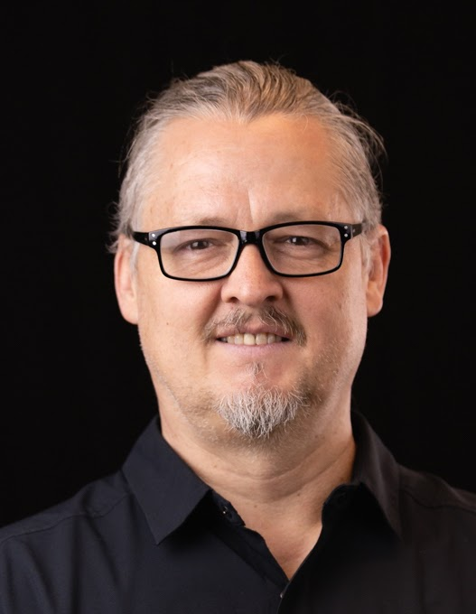